# Programming in R (774)

Pre-block Assignment 1 Department of Industrial Engineering Stellenbosch University 10 January 2021

**Responsible** Lecturer: Mr LE Burger (eldonburger@sun.ac.za)  
**Deadline**: 24 January 2022 @ 23:59  
**Total**: 40 marks

# Instructions

1. Pre-block assignment 1 evaluates your understanding of the content covered in topics 1, 2, 3 and 4 of the course
2. The assignment must be submitted on SUNLearn as an R Markdown document. To complete this assignment, complete the following steps:
   1. Download the *Rmd file*
   2. Rename and save *the Rmd file* as `????????PBA.Rmd`
   3. Complete all the questions in the provided *code chunks*:
   4. Complete the code in the provided *code chunks*:
      - Do not use any additional packages or libraries not included in the base installation of R
      - Code chunks that include the comment `#DO NOT EDIT` should not be modified
3. Before submitting your final document, make sure that your document can (i) execute from start to end and (ii) does not rely on any external files. Any additional files submitted will not be evaluated when the assignment is marked
4. Must follow the correct naming conventions

# Introduction

In this assignment, you will create an agent that can play the well-known card game blackjack. To implement an agent capable of playing blackjack you will be required to answer 10 coding questions. Each question is composed of instructions followed by a code chunk that you will have to complete to answer the question. In most cases, directly after a question, a code chunk is available to test your code. If the code that you provided works, you should not receive any error in the testing code chunks. The test provided is not necessarily complete or an indication of the final mark you will receive for a question but will be helpful to evaluate your code for typical flaws.

Question 0, which does not count any marks, is provided below to illustrate how to complete code chunks.

*Question 0*

Create an *atomic vector* called `my_test_vector` that contains the values `1`, `2`, `3` and `4` using the function `c()`. The object `my_test_vector` should be stored as an *integer*.

```r
# Normally you will have to complete the code below
my_test_vector <- c(1L, 2L, 3L, 4L)
my_test_vector
```

```
## [1] 1 2 3 4
```

```r
# TEST CODE
# DO NOT EDIT
if (!identical(my_test_vector, c(1L, 2L, 3L, 4L))){
  stop("Vector incorrect")
}
```

The above two code chunks should execute without any errors. However, if you defined `my_test_vector` incorrectly, the second code chunk will display an error. In other words, the second code chunk or test code chunk can be used to test your code.

# Game Set-up

To play a card game one or more decks of cards are required. Blackjack is played with a standard deck of 52 cards. A standard deck of cards has four suits namely: hearts, clubs, spades and diamonds. Each suite in the standard deck of cards contains thirteen cards: ace, 2, 3, 4, 5, 6, 7, 8, 9, 10, jack, queen and king

In blackjack, the suit of a card does not influence the game. Rather a value is assigned to each card:

- Each of the numeric cards is simply their face value. In other words, the 2 of hearts has a value of 2, the 3 of spades has a value of 3, etc.
- The jack, queen and kind are assigned the value 10.
- An ace can either have a value of 1 or 11 depending on the cards in your hand. For the moment simply assume that the value of an ace equals 1.

*Question 1* (2)

Create an *atomic vector* called `deck`. The *object* `deck` should store 52 *elements* of type *integer*. Each *element* stored in the *object* `deck` represents a card of a standard deck and is represented by its value. For example, the *vector* `c(1L, 2L, 3L, 4L)` represents the cards ace, two, three and four.

```r
# Complete the following code
deck <- rep(c(1L:10L, 10L, 10L, 10L), times = 4)
```

```r
# TEST CODE
# DO NOT EDIT
if (length(deck) != 52) stop("The object deck does not contain 52 elements")
if (typeof(deck) != "integer") stop("The object deck does not contain integer values")
if (sum(deck) != 340) stop("The values of the cards contained in the deck are incorrect")
if (!all(sapply(deck, is.element, set = c(1:10)))) {
  stop("The values of the cards contained in the deck are incorrect") }
```

Given a deck of cards, we require a method to draw a card from the deck.

*Question 2* (2)

Write a *function* called `draw_a_card` with one *argument* `deck`. The *function* `draw_a_card` should *return* the first *element* of the value passed to the `deck` argument

```r
# Complete the following code
draw_a_card <- function(deck) {
  return(deck[1])
}
```

```r
# TEST CODE
# DO NOT EDIT
if (draw_a_card(c(1000, 100, 10)) != 1000) {
  stop("The function does not return the first element")}
if (length(draw_a_card) != 1) stop("The function returns more than one value")
```

While the *function* defined in *question 2* will allow you to draw or select a card from the *object* `deck`, the *function* will always *return* the same card. In a normal game of blackjack, the deck will first be shuffled before a card is drawn. We can simplify the functionality of drawing a card, by simply selecting a random card from the values passed to the `deck` *argument* of the *function* `draw_a_card` each time the *function* `draw_a_card` is *called*.

*Question 3* (2)

Modify the *function* `draw_a_card` from *question 2*, to *return* one random card from the values passed to the `deck` *argument*. Use the *function* `sample()` inside the *function* `draw_a_card` to *return* a random card from the deck.

```r
# Complete the following code
draw_a_card <- function(deck) {
  card <- sample(deck, size = 1)
  return(card)
}
```

```r
# TEST CODE
# DO NOT EDIT
set.seed(1)
if (draw_a_card(c(1,2) == draw_a_card(c(1,2)))) stop("Random selection is not performed")
```

Blackjack is played between a player and a dealer. When the game starts both the player and dealer is dealt two cards each.

*Question 4* (2)

Use the *function* `draw_a_card`, developed in *question 3*, to assign two cards to the object `player_hand`. The object `player_hand` should be an atomic vector that stores values as *integers*.

```r
# Complete the following code
# draw one card
player_hand <- draw_a_card(deck)
# remove the card from the deck
ind <- which(player_hand == deck)[1]
deck <- deck[-ind]
# draw the second card
player_hand <- c(player_hand, draw_a_card(deck))
# remove the second card from the deck
ind <- which(player_hand[2] == deck)[1]
deck <- deck[-ind]
```

```r
# TEST CODE
# DO NOT EDIT
if (typeof(player_hand) != "integer") {
  stop("The object player_hand does not contain integer values") }
if (length(player_hand) != 2) stop("The object player_hand does not contain 2 elements")
```

The *object* `dealer_hand` can be defined in the same way as the *object* `player_hand`. For now, we skip defining the *object* `dealer_hand` as the logic is similar to the *object* `player_hand`.

# Determining the winner

In blackjack, a player wins the round if the score of the player is greater than the score of the dealer given that the score of the player does not exceed 21. The score of the player and the score of the dealer is computed in the exact same way. The score of a hand can be computed as follow:

- If the total value (sum of values) of cards in a hand exceeds 21, known as a bust, assign a score of 0 to the hand
- If a hand has an ace and the total value of the cards in hand is 11 or less (with the ace counting 1), count the ace as an 11 and not a 1 when computing the total value of cards
- If a hand contains exactly two cards and the total value of cards in a hand is equal to 21 - known as a “blackjack” - assign a value of 21.5 to the hand

*Question 5* (4)

Create a *function* called `score_hand` with a single *argument* `hand`. The *function* `score_hand` should compute the score of a hand based on the logic described above. The *function* should *return* the score as a single *numeric* value

```r
# Complete the following code
score_hand <- function(hand) {
  # the total value of cards in a hand
  total <- sum(hand)
  # if a hand has an ace and the total value of the cards in hand is 11 or less
  if(1L %in% hand & total <= 11) {
    # count the ace as an 11 and not a 1 when computing the total value of cards
    total <- total + 10
  }
  # if the total value of cards exceeds 21, assign a score of 0 to the hand
  if(total > 21) {
    # "bust"
    total <- 0
  }
  # if a hand contains exactly two cards and the total value of cards in a hand
  # is equal to 21, assign a value of 21.5 to the hand
  if(length(hand) == 2 & total == 21) {
    # "blackjack"
    total <- 21.5
  }
  return(total)
}
```

```r
# TEST CODE
# DO NOT EDIT
test_cards <- list(c(10, 1), c(10, 5, 6), c(10, 1, 1),
                   c(7, 6, 1, 5), c(3, 6, 1, 1),
                   c(2, 3, 4, 10), c(5, 1, 9, 1, 1),
                   c(5, 10, 7), c(10, 9, 1, 1, 1))
test_cards_val <- c(21.5, 21, 12, 19, 21, 19, 17, 0, 0)
if (!identical(test_cards_val, sapply(test_cards, score_hand))){
  stop("One or more tests failed") }
```

Given the score of the dealer and the score of a player, the amount of money that the player wins or losses can be computed as follow:

- If a player busts, the player loses their bet even if the dealer bust.
- If the score of a player is less than the score of the dealer, the player loses their bet.
- If the score of a player is greater than the score of the dealer, the player wins an amount equal to their initial bet. However, if the player has blackjack and the score of the player is greater than the score of the dealer, the player receives an additional amount of 0.5 times their bet.
- If the score of the player and the dealer is equal, the player keeps their bet.

*Question 6* (4)

Create a *function* called `payout` with three *arguments*: `player_score`, `dealer_score` and `bet`. Assign a default *value* of `1` to the *argument* `bet`. The goal of the *function* `payout` is to *return* the amount that the player should receive (positive number) or pay-in (negative number) based on the values passed to the `player_score`, `dealer_score` and `bet` *arguments*. The final amount should be returned as a single *numeric* value. For example, if the player wins without blackjack the function should return 1*bet; implying that the player wins 1*bet in this round.

```r
# Complete the following code
payout <- function(player_score, dealer_score, bet = 1) {
  # if a player busts or if the score of a player is less than the score of the dealer
  if(player_score == 0 | player_score < dealer_score) {
    # the player loses their bet
    pay <- -1*bet
  # otherwise, if the score of a player is greater than the score of the dealer
  } else if(player_score > dealer_score) {
    # the player wins an amount equal to their initial bet
    pay <- 1*bet
    # if the player has blackjack
    if(player_score == 21.5) {
      # the player receives an additional amount of 0.5 times their bet
      pay <- pay + 0.5*bet
    }
  # otherwise, if the score of the player and the dealer is equal
  } else {
    # the player keeps their bet
    pay <- 0
  }
  return(pay)
}
```

```r
# TEST CODE
# DO NOT EDIT
test_vals <- c(0, 16, 19, 20, 21, 21.5)
test_payout <- matrix(c( -1, 1, 1, 1, 1, 1.5,
                         -1, 0, 1, 1, 1, 1.5,
                         -1, -1, 0, 1, 1, 1.5,
                         -1, -1, -1, 0, 1, 1.5,
                         -1, -1, -1, -1, 0, 1.5,
                         -1, -1, -1, -1, -1, 0),
                      nrow = length(test_vals),
                      byrow = TRUE,
                      dimnames = list(dealer = test_vals, player = test_vals))

for(i in seq_along(test_vals)) {
  for(j in seq_along(test_vals)) {
    winnings = payout(dealer_score = test_vals[i], player_score = test_vals[j])
    if (winnings != test_payout[i,j]) stop("Incorrect payout returned")
    }
  }
```

# Game Actions

We now have a way to define a deck of cards, draw a card, determine the score of a hand and determine the final payout. Next, we focus on implementing the actions in a game of blackjack.

In blackjack, the player performs his/her actions first. Once the player has performed their actions, it is the dealers turn to perform actions. After the dealer has performed his/her actions, the game is concluded and the payout is determined.

The action that a player should take is based on their cards and the first card dealt to the dealer. The first card dealt to the dealer is visible to the player.

## Player actions

Depending on the rules used in blackjack, a player can have multiple actions available. We will simplify the problem by only considering the actions hit and stand.

1. When a player requests a “hit”, one card is drawn from the deck and added to the hand of the player
2. When a player chooses to “stand”, the turn of a player ends.

*Question 7* (2)

Define a *function* called `hit`. The *function* `hit` has only one *argument*, `hand`. When the *function* `hit` is *called* the *function* should add a card to the vector passed to the `hand` *argument* using the *function* `draw_a_card` defined in *question 3*. The *function* `hit` should *return* the original vector passed to the *argument* `hand` with a new card added to the last position of the vector.

```r
# Complete the following code
hit <- function(hand) {
  # add a card to the hand
  new_hand <- c(hand, draw_a_card(deck))
  return(new_hand)
}
```

```r
# TEST CODE
# DO NOT EDIT
if (length(hit(c(1,2,3))) != 4) stop("vector returned is an incorrect length")
```

## Dealer actions

Once the player chooses to stand or bust, it is the dealers turn to play. According to the rules of blackjack, the dealer must perform the action hit when the hand value of the dealer is less than 17 or a bust.

*Question 8* (4)

Create a *function* called `dealer_strategy`. The *function* `dealer_strategy` has only one *argument*, `hand`. The *function* `dealer_strategy` should *call* the *function* `hit` defined in *question 7* until the dealer score is more than 17 or the dealer bust. Note based on the value passed to the `hand` *argument*, the *function* ``hit` might be not be called, called once or called more than once.

```r
# Complete the following code
dealer_strategy <- function(hand) {
  # hand value of the dealer
  val <- score_hand(hand)
  # while the dealer score is less than 17 and not bust
  while(val < 17 & val != 0) {
    # the dealer performs the action hit
    hand <- hit(hand)
    # the new hand value of the dealer
    val <- score_hand(hand)
  }
  return(hand)
}
```

```r
# TEST CODE
# DO NOT EDIT
if (!identical(dealer_strategy(c(10,1)),c(10,1))) stop("Do not hit failed")
if (!identical(dealer_strategy(c(10,10,2)),c(10,10,2))) stop("Do not hit failed")
if (!identical(dealer_strategy(c(10,7)),c(10,7))) stop("Do not hit failed")
if (length(dealer_strategy(c(10,6))) != 3) stop("Hit once failed")
if (length(dealer_strategy(c(2))) < 3) stop("Hit more than once failed")
```

# Game agent

Now that we have implemented the game mechanics we can start by implementing our game agent – the player. To implement our game agent, we will make use of a lookup table to determine when the player should perform the action hit or when the player should perform the action stand.

```r
# DO NOT EDIT
df_action_lookup <- data.frame(hand_value = c(0:21, 2:11),
                               usable_ace = c(rep(FALSE, 22), rep(TRUE, 10)),
                               dealer_ace = c("Stand", rep("Hit", 16), rep("Stand", 5),
                                              rep("Hit", 7), rep("Stand", 3)),
                               dealer_2 = c("Stand", rep("Hit", 12), rep("Stand", 9),
                                            rep("Hit", 6), rep("Stand", 4)),
                               dealer_3 = c("Stand", rep("Hit", 12), rep("Stand", 9),
                                            rep("Hit", 6), rep("Stand", 4)),
                               dealer_4 = c("Stand", rep("Hit", 11), rep("Stand", 10),
                                            rep("Hit", 6), rep("Stand", 4)),
                               dealer_5 = c("Stand", rep("Hit", 11), rep("Stand", 10),
                                            rep("Hit", 6), rep("Stand", 4)),
                               dealer_6 = c("Stand", rep("Hit", 11), rep("Stand", 10),
                                            rep("Hit", 6), rep("Stand", 4)),
                               dealer_7 = c("Stand", rep("Hit", 16), rep("Stand", 5),
                                            rep("Hit", 6), rep("Stand", 4)),
                               dealer_8 = c("Stand", rep("Hit", 16), rep("Stand", 5),
                                            rep("Hit", 6), rep("Stand", 4)),
                               dealer_9 = c("Stand", rep("Hit", 16), rep("Stand", 5),
                                            rep("Hit", 7), rep("Stand", 3)),
                               dealer_10 = c("Stand", rep("Hit", 16), rep("Stand", 5),
                                             rep("Hit", 7), rep("Stand", 3)))
head(df_action_lookup)
```

|  | hand_value | usable_ace | dealer_ace | dealer_2 | dealer_3 | dealer_4 | dealer_5 | dealer_6 | dealer_7 | dealer_8 | dealer_9 | dealer_10 |
| --- | --- | --- | --- | --- | --- | --- | --- | --- | --- | --- | --- | --- |
| 1 | 0 | FALSE | Stand | Stand | Stand | Stand | Stand | Stand | Stand | Stand | Stand | Stand |
| 2 | 1 | FALSE | Hit | Hit | Hit | Hit | Hit | Hit | Hit | Hit | Hit | Hit |
| 3 | 2 | FALSE | Hit | Hit | Hit | Hit | Hit | Hit | Hit | Hit | Hit | Hit |
| 4 | 3 | FALSE | Hit | Hit | Hit | Hit | Hit | Hit | Hit | Hit | Hit | Hit |
| 5 | 4 | FALSE | Hit | Hit | Hit | Hit | Hit | Hit | Hit | Hit | Hit | Hit |
| 6 | 5 | FALSE | Hit | Hit | Hit | Hit | Hit | Hit | Hit | Hit | Hit | Hit |

*Question 9* (6)

Create a *function* called `lookup_action` with two *arguments* `hand` and `dealer_card`. The *function* `lookup_action` should *return* whether the player should “Hit” or “Stand” using the *data frame* `df_action_lookup`.

```r
# Complete the following code
lookup_action <- function(hand, dealer_card) {
  # hand value
  val <- sum(hand)
  # does the hand of the player contain a useable ace?
  ace <- (1L %in% hand) & (val <= 11)
  # if the hand value exceeds 21, assign a score of 0 to the hand
  if(val > 21) {
    val <- 0
  }
  # look up whether the player should "Hit" or "Stand"
  r <- which(df_action_lookup$hand_value == val & df_action_lookup$usable_ace == ace)
  action <- df_action_lookup[r, dealer_card + 2]
  return(action)
}
```

```r
# TEST CODE
# DO NOT EDIT
if (!lookup_action(c(10,6), 1) == "Hit") stop("Wrong value returned")
if (!lookup_action(c(10,6), 2) == "Stand") stop("Wrong value returned")
if (!lookup_action(c(10,3,3), 2) == "Stand") stop("Wrong value returned")
if (!lookup_action(c(8,1), c(10)) == "Stand") stop("Wrong value returned")
if (!lookup_action(c(7,2), c(10)) == "Hit") stop("Wrong value returned")
if (!lookup_action(c(10,4,1,10), 10) == "Stand") stop("Wrong value returned")
```

# Simulating a game

We now have all the pieces in place to evaluate the effectiveness of our player. To determine the effectiveness of our player, we will simulate multiple games.

*Question 10* (12)

Write a *function* named `play_game` that:

1. Creates a deck of card, called `deck`, using the code defined in *question 1*
2. Deals two cards from the deck of cards defined in the previous step using the *function* defined in *question 3*. The two cards should be added to the *integer* vector `player_hand`
3. Deals two cards from the deck of cards defined in the previous step using the *function* defined in *question 3*. The two cards should be added to the *integer* vector `dealer_hand`
4. *Call* the *function* `lookup_action` defined in *question 9* to determine the actions of the player. The *function* `lookup_action` might have to be called more than once
5. Call the *function* `dealer_strategy` defined in *question 8* to determine the actions of the dealer
6. Calculate the player score using the *function* `socre_hand` defined in *question 5*
7. Calculate the dealer score using the *function* `socre_hand` defined in *question 5*
8. Determine and *return* the payout using the function `payout` defined in *question 6*

You can assume that a bet of 1 will always be used.

```r
# Complete the following code
play_game <- function() {
  # create a deck of cards
  deck <- rep(c(1L:10L, 10L, 10L, 10L), times = 4)

  # deal two cards from the deck of cards to the player
  # draw one card
  player_hand <- draw_a_card(deck)
  # remove the card from the deck
  ind <- which(player_hand == deck)[1]
  deck <- deck[-ind]
  # draw the second card
  player_hand <- c(player_hand, draw_a_card(deck))
  # remove the second card from the deck
  ind <- which(player_hand[2] == deck)[1]
  deck <- deck[-ind]

  # deal two cards from the deck of cards to the dealer
  # draw one card
  dealer_hand <- draw_a_card(deck)
  # remove the card from the deck
  ind <- which(dealer_hand == deck)[1]
  deck <- deck[-ind]
  # draw the second card
  dealer_hand <- c(dealer_hand, draw_a_card(deck))
  # remove the second card from the deck
  ind <- which(dealer_hand[2] == deck)[1]
  deck <- deck[-ind]

  # determine the action of the player
  player_action <- lookup_action(player_hand, dealer_hand[1])
  # while player requests a "hit"
  while(player_action == "Hit") {
    # draw and add one card to player's hand
    player_hand <- hit(player_hand)
    # remove the card from the deck
    ind <- which(tail(player_hand, 1) == deck)[1]
    deck <- deck[-ind]
    # determine the next action of the player
    player_action <- lookup_action(player_hand, dealer_hand[1])
  }

  # determine the actions of the dealer
  dealer_hand <- dealer_strategy(dealer_hand)

  # calculate the player score
  player_score <- score_hand(player_hand)

  # calculate the dealer score
  dealer_score <- score_hand(dealer_hand)

  # determine and return the payout
  pay <- payout(player_score, dealer_score)
  return(pay)
}
```

Given the *function* `play_game`, we can run multiple games to determine how good our player strategy is. The results can be visualised as a bar plot:

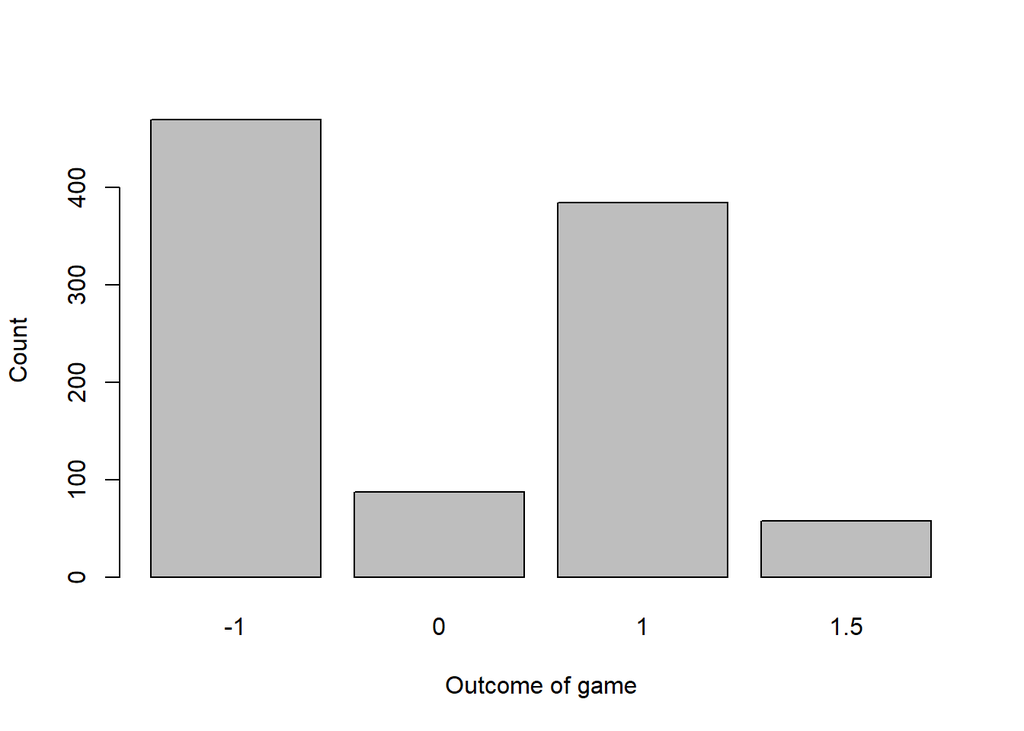

```r
# DO NOT EDIT
barplot(summary(factor(replicate(1000, play_game()))),
        xlab = "Outcome of game",
        ylab = "Count")
```